# Recruit Restaurant Visitor Forecasting

#### A Kaggle Competition Kernel

Created by

Shaoqian Tang  
Yiqing Yang  
Siyu Wang  
Yiyi Han  
Anil Jacob

[figure not shown]

## Project Overview

Click Here To View Competition Page

This project aims to help restaurants predict **the number of customers to expect** on a daily basis to optimize inventory and staff resources.

1. Environment Setup  
   1.1 Loading Needed Packages  
   1.2 Loading Available Datasets  
   1.3 Data Disctionary
2. Data Exploration & Feature Engineering  
   2.1 Train Store Information  
   2.2 Visitor Information  
   2.3 Reservations  
   2.4 Area  
   2.5 Genre
3. Data Preparation for Modeling
4. Modeling  
   4.1 Loading Packages & Setup  
   4.2 Define RMSLE  
   4.3 Set up Cross Validation  
   4.4 Linear Regression  
   4.5 Random Forest  
   4.6 XGBoost  
   4.7 Model Comparison
5. Deploy the Model
6. Further Directions

<a id = '1'></a>

## Step 1: Setting up the Environment

<a id = '1.3'></a>

### 1.3 Data Dictionaries

**Data Sources**

- Hot Pepper Gourmet (hpg): similar to Yelp, here users can search restaurants and also make a reservation online
- AirREGI / Restaurant Board (air): similar to Square, a reservation control and cash register system

**Table 1: air_reserve**

| Column Name | Column Description |
| --- | --- |
| air_store_id | restaurant id in the air system |
| visit_datetime | time of the reservation |
| reserve_datetime | time the reservation was made |
| reserve_visitors | number of visitors for that reservation |

**Table 2: hpg_reserve**

| Column Name | Column Description |
| --- | --- |
| hpg_store_id | restaurant id in the hpg system |
| visit_datetime | time of the reservation |
| reserve_datetime | time the reservation was made |
| reserve_visitors | number of visitors for that reservation |

**Table 3: air_store_info**

| Column Name | Column Description |
| --- | --- |
| air_store_id | restaurant id in the air system |
| air_genre_name | genre in the air system |
| air_area_name | area of the restaurant in the air system |
| latitude | latitude |
| longitude | longitude |

**Table 4: hpg_store_info**

| Column Name | Column Description |
| --- | --- |
| hpg_store_id | restaurant id in the hpg system |
| hpg_genre_name | genre in the hpg system |
| hpg_area_name | area of the restaurant in the hpg system |
| latitude | latitude |
| longitude | longitude |

**Table 5: air_visit_data**

| Column Name | Column Description |
| --- | --- |
| air_store_id | restaurant id in the air system |
| visit_date | date |
| visitors | the number of visitors to the restaurant on the date |

**Table 6: date_info**

| Column Name | Column Description |
| --- | --- |
| calendar_date | date |
| day_of_week | day of the week |
| holiday_flg | if the day is a holiday in Japan |

<a id = '2'></a>

## Step 2: Data Exploration and Feature Engineering

#### FIGURE 1: Store Distribution map

The two maps below show the distribution of stores recorded in air and hpg. While the overall distribution looks similar for both sources, hpg seems to include more restaurants than air.

```
Text(0.5,1,'air_store distribution')
```

```
Text(0.5,1,'hpg_store distribution')
```

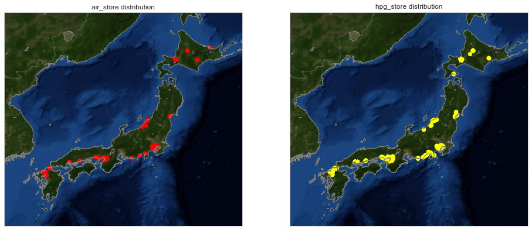

```python
fig,ax = plt.subplots(1,2,figsize = (16,16))

color = ['red','yellow']
title = ['air_store distribution', 'hpg_store distribution']
for i,data in enumerate([air_store_info,hpg_store_info]):
    m = Basemap(resolution = 'h',lon_0 = 0, lat_0 = 0,llcrnrlon=127, urcrnrlon=147,
                      llcrnrlat=29, urcrnrlat=47, ax = ax[i])
    m.bluemarble()
    m.drawcoastlines(color = 'gray')
    m.drawcountries(color = 'gray')
    m.drawstates(color = 'gray')
    m.scatter(data['longitude'], data['latitude'], latlon = True, color = color[i], marker='o')
    ax[i].set_title(title[i])
```

```python
# Let's see the exact number of stores in each dataset
hpg_store_num = hpg_store_info['hpg_store_id'].nunique()
air_store_num = air_store_info['air_store_id'].nunique()

print(f'There are {hpg_store_num} hpg stores')
print(f'There are {air_store_num} air stores')
```

```
There are 4690 hpg stores
There are 829 air stores
```

<a id = '2.2'></a>

### 2.2 Visitor Information

#### FIGURE 2: Total Visitors by Visit Date (Daily/ Weekly/ Monthly)

Visitor data is only available from the air records.

**Observations:**

- The Daily Visitors graph shows a clear cyclical trend over days in a week.
- There is no significant upwarding trend over time except the huge jump in July 2016 (as we explore later, this is due to the increasing number of restaurants, either newly-opened or newly-recorded).
- January is the low season for the Japanese Restaurant Industry.

```
[Text(0,0.5,'Daily visitors'), Text(0.5,0,'')]
```

```
[Text(0,0.5,'Weekly visitors'), Text(0.5,0,'')]
```

```
[Text(0,0.5,'Monthly visitors'), Text(0.5,0,'')]
```

```
Text(0.5,0,'visit date')
```

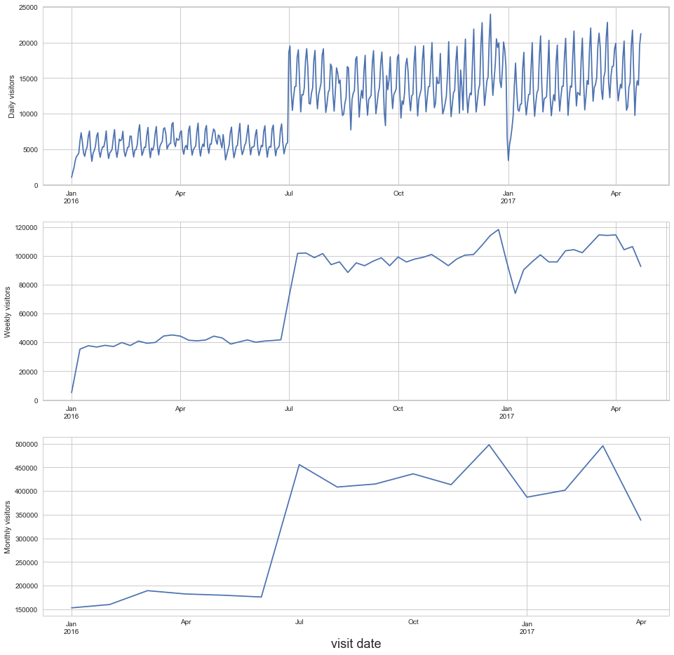

```python
fig,ax = plt.subplots(3,1, figsize = (16,16))
Fre = ["Daily", "Weekly", "Monthly"]

for i,fre in enumerate(["D","W","M"]):
    air_visit_data.groupby('visit_date')['visitors'].sum().resample(fre).sum().plot(ax = ax[i])
    ax[i].set(ylabel = (Fre[i] + ' visitors'), xlabel = "")
plt.xlabel('visit date', fontsize = 18)
```

<a id = '2.3'></a>

### 2.3 Reservations

- **How many unique stores are reserved?**
- **How many unique stores are visited?**

```python
num_reserve = total_reserve['store_id'].nunique()
num_visit = air_visit_data['air_store_id'].nunique()
print("{} stores are reserved".format(num_reserve))
print("{} stores are visited".format(num_visit))
```

```
333 stores are reserved
829 stores are visited
```

#### FIGURE 3: Total Number of Reservations VS Total Number of Visitors

**Observations:**

- In general, reservations are only a small portion of total visits.
- There is a huge jump in reservation numbers in November 2016.
- Reservation trend does not seem to reflect visitor trend well.

```
Text(0,0.5,'Visitors')
```

```
Text(0.5,0,'Date')
```

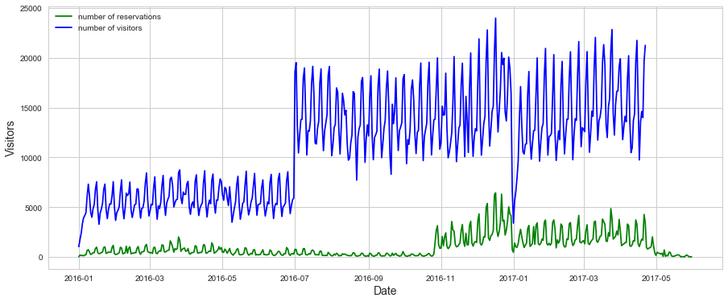

```python
reserve_by_date = total_reserve.groupby('date').sum().reset_index()
visit_by_date = air_visit_data.groupby('visit_date').sum().reset_index()

plt.plot(reserve_by_date['date'], reserve_by_date['reserve_visitors'], color = 'green', label = 'number of reservations')
plt.plot(visit_by_date['visit_date'], visit_by_date['visitors'], color = 'blue', label = 'number of visitors')
plt.legend(loc = 'upper left')
plt.ylabel('Visitors', fontsize = 14)
plt.xlabel('Date', fontsize = 14)
```

- **Is the increse at 2016-07 cause by an increase in the number of stores?**
- **Yes**

```python
air_visit_data_05 = air_visit_data[(air_visit_data['visit_date'].apply(lambda x: x.year) == 2016) & (air_visit_data['visit_date'].apply(lambda x: x.month) < 6)]
air_visit_data_07 = air_visit_data[(air_visit_data['visit_date'].apply(lambda x: x.year) == 2016) & (air_visit_data['visit_date'].apply(lambda x: x.month) > 7)]
air_visit_data_05['air_store_id'].nunique()
air_visit_data_07['air_store_id'].nunique()
```

```
316
```

```
818
```

#### FIGURE 4: Visit Time VS Reservation Time

**Observations:**

- Most activities happen in the afternoon and evening.
- Compared to dinner, very few people have lunch outside.

```
 <a list of 6 Text xticklabel objects>)
```

```
Text(0,0.5,'reserve visitors')
```

```
Text(0.5,0,'time')
```

```
(0, 86400)
```

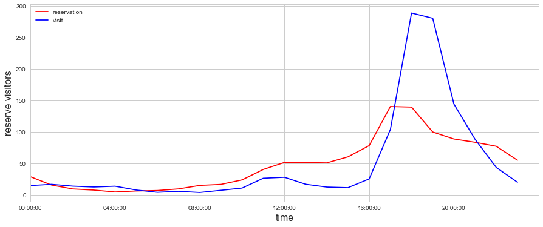

```python
df1 = total_reserve.groupby('reserve_datetime')['reserve_visitors'].sum()
reserve_time = df1.groupby(df1.index.time).mean().reset_index()

df2 = total_reserve.groupby('visit_datetime')['reserve_visitors'].sum()
visit_time = df2.groupby(df2.index.time).mean().reset_index()

hourly_ticks = 4 * 60 * 60 * np.arange(6) #4 hours per interval, 60 min per hour, 60 second per min, 6(24/4)
plt.plot(reserve_time['index'], reserve_time['reserve_visitors'],color = 'red', label = 'reservation')
plt.plot(visit_time['index'], visit_time['reserve_visitors'], color = 'blue', label = 'visit')
plt.xticks(hourly_ticks)
plt.legend(loc = 'upper left')
plt.ylabel('reserve visitors', fontsize = 16)
plt.xlabel('time', fontsize = 16)
plt.xlim(0,4 * 60 * 60 * 6)
```

#### FIGURE 6: Average number of reserved visitors by reservation time on weekday and weekend

**Observations:**

- Overall, there are more reserved visitors on weekdays.
- However, the overall pattern across reservation time are the same betwwen weekday and weekend.

```
(0, 86400)
```

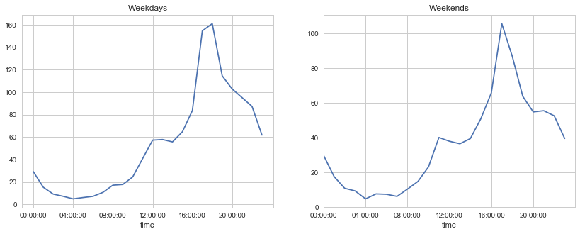

```python
weekend = np.where(df1.index.weekday < 5, 'Weekday', 'Weekend')
by_time = df1.groupby([weekend, df1.index.time]).mean()

fig, ax = plt.subplots(1, 2, figsize=(14, 5))
by_time.ix['Weekday'].plot(ax=ax[0], title='Weekdays',
                           xticks=hourly_ticks)
by_time.ix['Weekend'].plot(ax=ax[1], title='Weekends',
                           xticks=hourly_ticks);
plt.xlim(0,4 * 60 * 60 * 6)
```

#### FIGURE 7: Average Number of Visitors per Store for Holidays and non-Holidays.

**Observations:**

- There are more visitos on holidays. We need to do a statistical test to see if the difference is significant.

```
Text(0,0.5,'visitors')
```

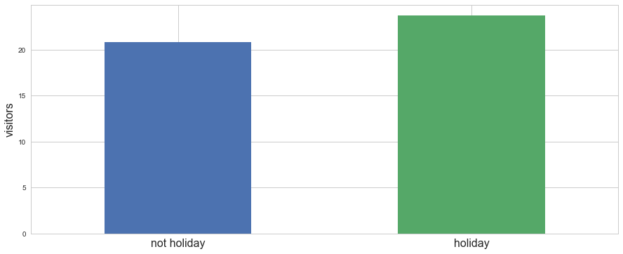

```python
date_info = date_info.rename(columns = {'calendar_date':'visit_date'})
air_holiday = air_visit_data.merge(date_info, how = 'inner', on = 'visit_date')
holiday = air_holiday.groupby('holiday_flg')['visitors'].mean()
holiday.index = ['not holiday', 'holiday']
holiday.plot(kind = 'bar')
plt.xticks(rotation = 'horizontal', fontsize = 16)
plt.ylabel('visitors', fontsize =16)
```

```python
date_info = date_info.rename(columns = {'calendar_date':'visit_date'})
air_holiday = air_visit_data.merge(date_info, how = 'inner', on = 'visit_date')
holiday = air_holiday.groupby('holiday_flg')['visitors'].mean()
holiday.index = ['not holiday', 'holiday']
holiday

# Hypothesis testing
holiday_0 = air_holiday[air_holiday['holiday_flg'] == 0]['visitors']
holiday_1 = air_holiday[air_holiday['holiday_flg'] == 1]['visitors']
stats.ttest_ind(holiday_0, holiday_1)
```

```
not holiday    20.828064
holiday        23.703327
Name: visitors, dtype: float64
```

```
Ttest_indResult(statistic=-18.90934338944833, pvalue=1.0851683125688138e-79)
```

Seems holiday has even a positive influence.

<a id = '2.4'></a>

### 2.4 Area

#### FIGURE 8: Average Number of Visitors by Area

**Observations:**

- Shizuoka-ken has the highest average number of visitors while Fukuoka-ken has the lowest.

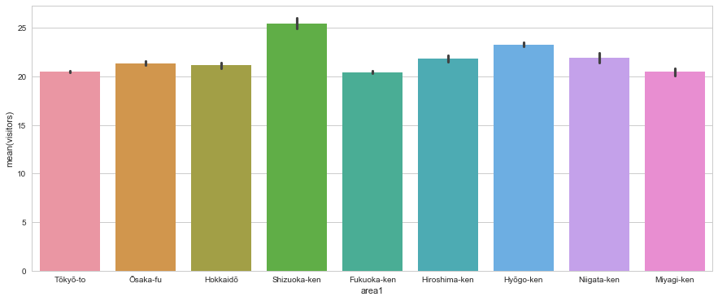

```python
#area1 = store_info.groupby("area1")["visitors"].mean().reset_index()
#area1.head(3)
sns.barplot(x = store_info["area1"], y=store_info["visitors"])
```

<a id = '2.5'></a>

### 2.5 Genre

#### FIGURE 9: Average Number of Visitors by Genre

**Observations:**

- Asian Restaurants are the most popular.
- Bar/Cocktail is the least popular.

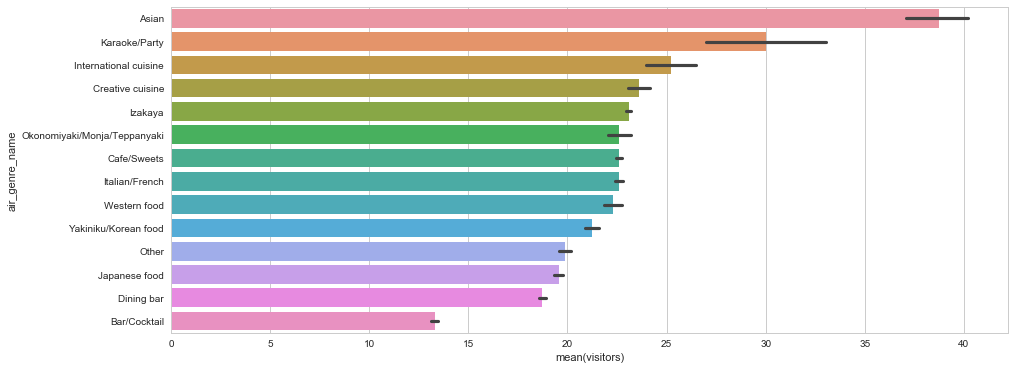

```python
order_genre = store_info.groupby(["air_genre_name"])["visitors"].mean().reset_index().sort_values("visitors",ascending = False)
sns.barplot(y = store_info["air_genre_name"], x=store_info["visitors"],order= order_genre["air_genre_name"])
```

<a id = '3'></a>

## Step 3: Data Preparation for Modeling

```python
Xtrain.info()
```

```
<class 'pandas.core.frame.DataFrame'>
Int64Index: 252108 entries, 0 to 252107
Data columns (total 23 columns):
holiday_flg           252108 non-null int64
fri_or_sat            252108 non-null int64
month                 252108 non-null int64
air_genre_name        252108 non-null int64
latitude              252108 non-null float64
longitude             252108 non-null float64
area1                 252108 non-null int64
area2                 252108 non-null int64
area3                 252108 non-null int64
area1_genre_max       252108 non-null int64
area1_genre_median    252108 non-null float64
area1_genre_mean      252108 non-null float64
min_all               252108 non-null int64
max_all               252108 non-null int64
median_all            252108 non-null float64
mean_all              252108 non-null float64
min_weekday           252108 non-null int64
max_weekday           252108 non-null int64
median_weekday        252108 non-null float64
mean_weekday          252108 non-null float64
reserve_visitors      252108 non-null float64
delta_2days           252108 non-null float64
delta_long            252108 non-null float64
dtypes: float64(11), int64(12)
memory usage: 46.2 MB
```

<a id = '4'></a>

## Step 4: Modeling

<a id = '4.2'></a>

### 4.2 Define RMSLE

[figure not shown]

```python
def rmsle(y, yp):
    """
    Compute the Root Mean Squared Log Error for hypthesis yp and targets y
    Args:
        yp - numpy array containing predictions with shape (n_samples, n_targets)
        y - numpy array containing targets with shape (n_samples, n_targets)
    """
    return np.sqrt(np.square(np.log1p(yp) - np.log1p(y)).mean())

acc_scorer = make_scorer(score_func = rmsle, greater_is_better = False)
```

<a id = '4.4'></a>

### 4.4 Linear Rregression

```python
def linear_reg(train_x,train_y,test_x):
    x = sm.add_constant(train_x, has_constant='add')
    est = sm.OLS(train_y, x)
    est = est.fit()
    lm_summary = est.summary()
    pred_x = sm.add_constant(test_x, has_constant='add')
    pred_y= est.predict(pred_x)
    return (lm_summary,pred_y)
```

```python
k = 5
model = "linear_reg"
rmsle_ols = cv_rmsle(k, model, Xtrain,Ytrain)
rmsle_ols = np.mean(rmsle_ols)
rmsle_ols
```

```
finish 0 round of linear_reg, rmlse = 0.5337994459742469
finish 1 round of linear_reg, rmlse = 0.5322499517236181
finish 2 round of linear_reg, rmlse = 0.5314546875619566
finish 3 round of linear_reg, rmlse = 0.5354579542122219
finish 4 round of linear_reg, rmlse = 0.533287112191213
```

```
0.5332498303326514
```

<a id = '4.5'></a>

### 4.5 Random Forest

#### grid search to find optimal parameters for random forest

```python
acc_scorer = make_scorer(score_func = rmsle, greater_is_better = False)
model = RandomForestRegressor()
parameters = {'n_estimators': [100],
              'max_features': ['log2', 'sqrt','auto'], #The number of features to consider when looking for the best split
              'max_depth': [5, 10,12],
              'min_samples_split': [2, 3, 5],
             }
grid_obj = GridSearchCV(model, parameters, scoring=acc_scorer)
grid_obj = grid_obj.fit(train_x, train_y)
model_params = grid_obj.best_params_
model_params
#grid_obj.best_score_
```

```
{'max_depth': 10,
 'max_features': 'auto',
 'min_samples_split': 2,
 'n_estimators': 100}
```

#### FIGURE 11: Top Features pick by Random Forest Algorithm

**Interpretations:**

- min_weekday: minimum number of visitors for same restaurant on the same weekday
- median_all: median mumber of visitors for same restaurant
- delta_long: if the dfference between reservation time and visit tiem longer than 7 days
- latitude: latitude of the resaturant
- area1_gerne_max: maximum number of visitors for the restaurant with same gerne in same area1

```
0.5257264891187505
```

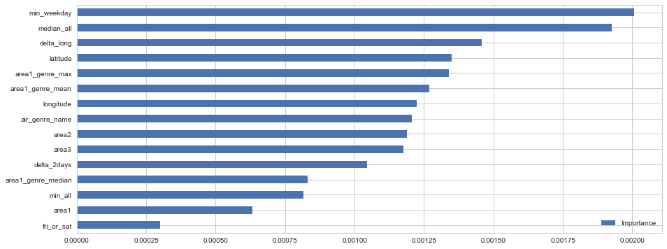

```python
model_params = {'max_depth': 10,
 'max_features': 'auto',
 'min_samples_split': 2,
 'n_estimators': 100}
forest, pred_testy = random_forest(train_x,train_y,test_x,**model_params)
rmsle(test_y,pred_testy)
plot_rf_importance(forest)
```

```python
k = 5
model = "random_forest"
model_params = {'max_depth': 10,
 'max_features': 'auto',
 'min_samples_split': 3,
 'n_estimators': 60}
rmsle_rf = cv_rmsle(k, model, Xtrain,Ytrain,**model_params)
rmsle_rf = np.mean(rmsle_rf)
rmsle_rf
```

```
finish 0 round of random_forest, rmlse = 0.5255914468507514
finish 1 round of random_forest, rmlse = 0.5255024307516576
finish 2 round of random_forest, rmlse = 0.5241612343155102
finish 3 round of random_forest, rmlse = 0.5226477454740996
finish 4 round of random_forest, rmlse = 0.5309899640537721
```

```
0.5257785642891581
```

<a id = '4.6'></a>

### 4.6 XGBoost

#### grid search to find optimal parameters for xgboost

```python
acc_scorer = make_scorer(score_func = rmsle, greater_is_better = False)
model = XGBClassifier(nthread=3, scale_pos_weight=1, seed=27)
model_params = {'learning_rate': [0.05],
              'n_estimators': [150],
              'max_depth': [8, 10, 12],
              'subsample': [0.7,0.8],
              'colsample_bytree': [0.7],
              'objective': ['reg:linear'],
              'min_child_weight': [1],
              'gamma': [0]
             }
grid_obj = GridSearchCV(model, model_params, scoring=acc_scorer)
grid_obj = grid_obj.fit(test_x, test_y)
model_params = grid_obj.best_params_
model_params
#grid_obj.best_score_
```

[output not shown]

[output cut: 16 more lines]

```
{'colsample_bytree': 0.7,
 'gamma': 0,
 'learning_rate': 0.05,
 'max_depth': 8,
 'min_child_weight': 1,
 'n_estimators': 150,
 'objective': 'reg:linear',
 'subsample': 0.7}
```

```python
k = 5
xgb_params = {
    'eta': 0.05,
    'max_depth': 8,
    'subsample': 0.7,
    'colsample_bytree': 0.7,
    'objective': 'reg:linear',
    'eval_metric': 'rmse',
    'silent': 1
}
model = "xgb_model"
model_params = {
   "xgb_params": xgb_params,
    "num_round": 70
}

rmsle_xgb = cv_rmsle(k, model, Xtrain,Ytrain,**model_params)
rmsle_xgb = np.mean(rmsle_xgb)
rmsle_xgb
```

```
finish 0 round of xgb_model, rmlse = 0.5162937433224921
finish 1 round of xgb_model, rmlse = 0.5227695325892232
finish 2 round of xgb_model, rmlse = 0.5188040666327323
finish 3 round of xgb_model, rmlse = 0.5201080802747058
finish 4 round of xgb_model, rmlse = 0.5156263027321398
```

```
0.5187203451102587
```

<a id = '4.7'></a>

### 4.7 Model Comparison

```python
cv_compare = {"ols": rmsle_ols,
            "random forest": rmsle_rf,
            "xgboost": rmsle_xgb

}
cv_compare = pd.DataFrame.from_dict(cv_compare,orient='index')
cv_compare.columns = ["rmsle"]
cv_compare
```

|  | rmsle |
| --- | --- |
| ols | 0.533250 |
| random forest | 0.525779 |
| xgboost | 0.518720 |

<a id = '5'></a>

## Step 5: Deploy the Model

- What if restaurant air_00a91d42b08b08d9 want to know its visitors on 2017-04-23?
- Can the restaurant get the predicted result directly without running through this whole complex notebook?
- **Yes!**
- Save the model and related table into S3
- create an local endpoint using Flask or create an AWS endpoint using Lambda and Serverless
- post interested id_date to endpoint, the web server can directly return the predicted result

#### Save Model

```python
xgboost_model.save_model('../model/xgb02.model')
```

#### Create endpoint

- **Local endpoint using Flask:** py//deploy_flask_cbre.py
- **AWS endpoint using Serverless:** cbrelambda//handler_cbre.py

#### Post interested id_date to endpoint

- curl -H "Content-Type: application/json" -X POST -d '{"id_date": "air_00a91d42b08b08d9_2017-04-23"}' http://127.0.0.1:5050/visit
- curl -H "Content-Type: application/json" -X POST -d '{"id_date":"air_00a91d42b08b08d9_2017-04-23"}' https://vnnxb5ok7i.execute-api.us-east-1.amazonaws.com/dev/visit

<a id = '6'></a>

## Step 6: Further Directions

What we have now is definitely not the endpoint of this analysis. A data scientist could continue work forever to improve the performance of the models. Moving Forward, there are some areas that we would like to address and further explore to improve the analysis:

**More Feature Explorations**

In our analysis, we used features that are provided in the Kaggle dataset. This limits our choice of features. Number of visitors to a restaurant certainly depends more things on its reservations, genre or area. There could also be a correlation between the social-economic conditions of the neighborhood, other attributes of the restaurant itself and the number of visitors. Therefore, it would be valuable for us to also explore these other features as well.

**Times Series Models**

We have is a time series problem. In this case, it could also be valuable to explore ARIMA models with the dataset. In this exercise, we chose other methods to start with because we did not observe a clear pattern and we thought we might not have enough data points. However, moving forward, it still worth trying it out and comparing it with the other models we built.